# reprex

Allison Horst

8/19/2021

Your job is to identify an error, then make a reproducible example that would help future you or someone else understand how to write the code correctly. In other words, your reprex code will *work* and offer a solution to the error thrown in each of the following examples.

Data are in `AS00601.csv` (and read in correctly below as `mack_creek_vertebrates`).

Data package title: Aquatic Vertebrate Population Study in Mack Creek, Andrews Experimental Forest, 1987 to present

**Citation:** Gregory, S.V. and I. Arismendi. 2020. Aquatic Vertebrate Population Study in Mack Creek, Andrews Experimental Forest, 1987 to present ver 14. Environmental Data Initiative. https://doi.org/10.6073/pasta/7c78d662e847cdbe33584add8f809165

### Read in the data

There are no problems here.

```r
mack_creek_vertebrates <- read_csv(here("AS00601.csv"))
```

### reprex 1

Identify what is causing the problem in the code below (there’s only one thing). Then, create a very simple reprex that would help yourself, future you, or a colleague fix the problem. **Post your reprex as an issue in your own fork on GitHub.**

```r
# Example 1:
mack_creek_lengths <- mack_creek_vertebrates %>%
  clean_names() %>%
  select(year:sampledate) %>%
  filter(section == "CC") %>%
  mutate(across(where(is.character), tolower)) %>%
  drop_na(species) %>%
  group_by(species) %>%
  summarize(mean_length_cm = mean(length1, na.rm = TRUE),
            sd_length_cm = sd(length1, na.rm = TRUE)) %>%
  ungroup()
```

### reprex 2

Identify what is causing the problem in the code below (there’s only one thing). Then, create a very simple reprex that would help yourself, future you, or a colleague fix the problem. **Post your reprex as an issue in your own fork on GitHub.**

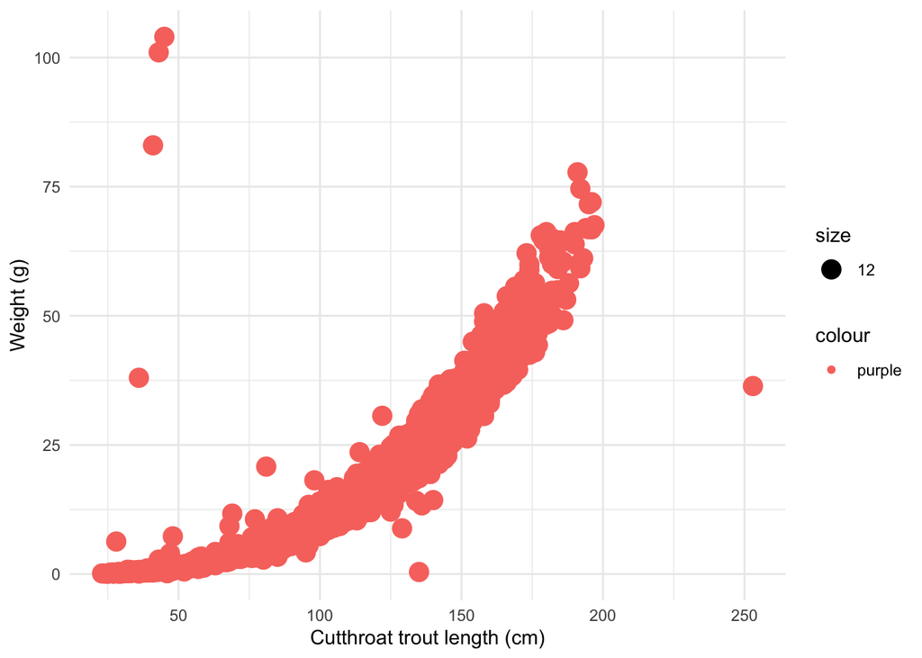

```r
# Example 2:
mack_creek_vertebrates %>%
  clean_names() %>%
  filter(species == "ONCL") %>%
  ggplot(aes(x = length1, y = weight)) +
         geom_point(aes(size = 12, color = "purple")) +
         theme_minimal() +
         labs(x = "Cutthroat trout length (cm)",
              y = "Weight (g)")
```